# Principal Component Analysis

Dataset raw_data

This dataset contains 195 individuals and 11 variables, 1 quantitative variable is considered as illustrative, 5 qualitative variables are considered as illustrative.

### 1. Study of the outliers

The analysis of the graphs does not detect any outlier.

### 2. Inertia distribution

The inertia of the first dimensions shows if there are strong relationships between variables and suggests the number of dimensions that should be studied.

The first two dimensions of PCA express **82.58%** of the total dataset inertia ; that means that 82.58% of the individuals (or variables) cloud total variability is explained by the plane. This percentage is high and thus the first plane represents an important part of the data variability. This value is strongly greater than the reference value that equals **48.13%**, the variability explained by this plane is thus highly significant (the reference value is the 0.95-quantile of the inertia percentages distribution obtained by simulating 1422 data tables of equivalent size on the basis of a normal distribution).

From these observations, it is probably not useful to interpret the next dimensions.

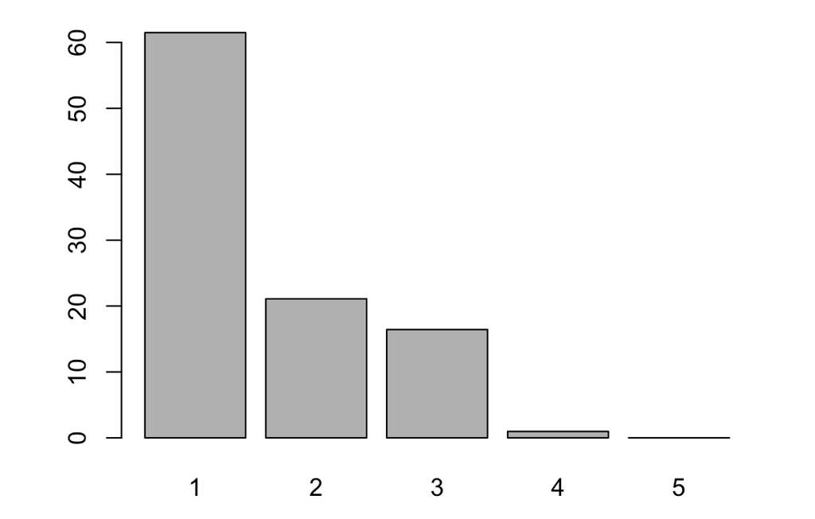

**Figure 2 - Decomposition of the total inertia on the components of the PCA** *The first factor is major: it expresses itself 61.49% of the data variability.* *Note that in such a case, the variability related to the other components might be meaningless, despite of a high percentage.*

An estimation of the right number of axis to interpret suggests to restrict the analysis to the description of the first 1 axis. These axis present an amount of inertia greater than those obtained by the 0.95-quantile of random distributions (61.49% against 26.06%). This observation suggests that only this axis is carrying a real information. As a consequence, the description will stand to these axis.

### 3. Description of the dimension 1

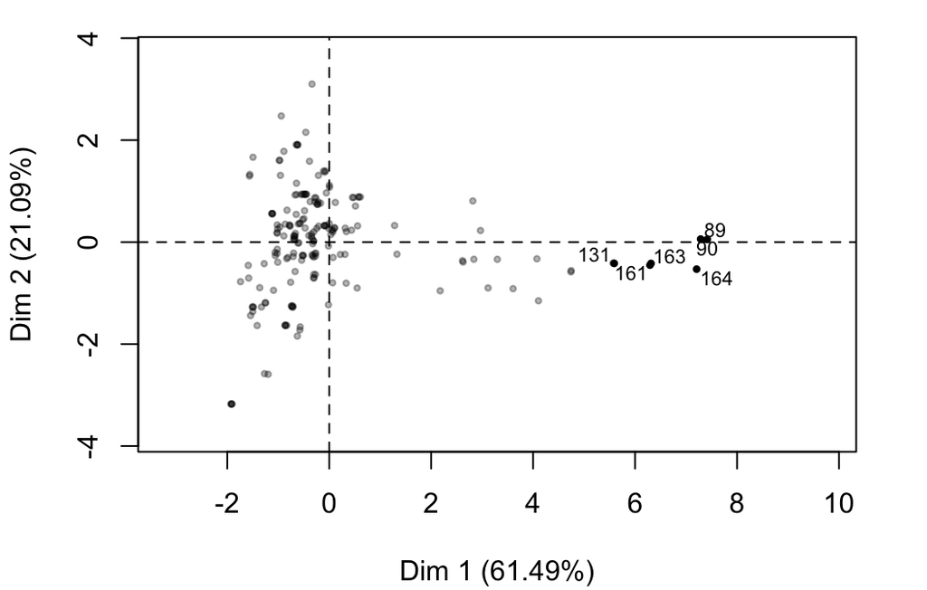

**Figure 3.1 - Individuals factor map (PCA)** *The labeled individuals are those with the higher contribution to the plane construction.*

The Wilks test p-value indicates which variable factors are the best separated on the plane (i.e. which one explain the best the distance between individuals).

```
## Impermeability   Raw.Material          Shape       Supplier      Finishing
##   1.399363e-27   1.020729e-22   2.010881e-11   3.371746e-07   3.945462e-01
```

The best qualitative variable to illustrate the distance between individuals on this plane is : *Impermeability*.

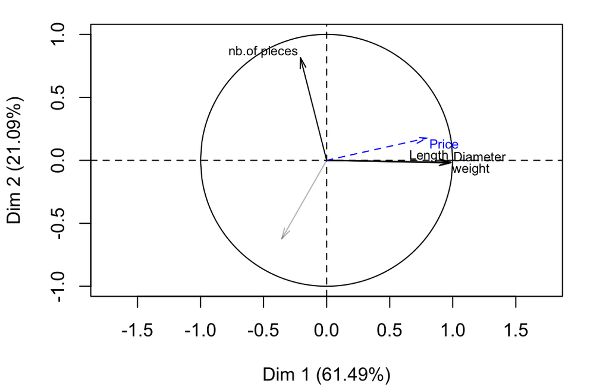

**Figure 3.3 - Variables factor map (PCA)** *The variables in black are considered as active whereas those in blue are illustrative.* *The labeled variables are those the best shown on the plane.*

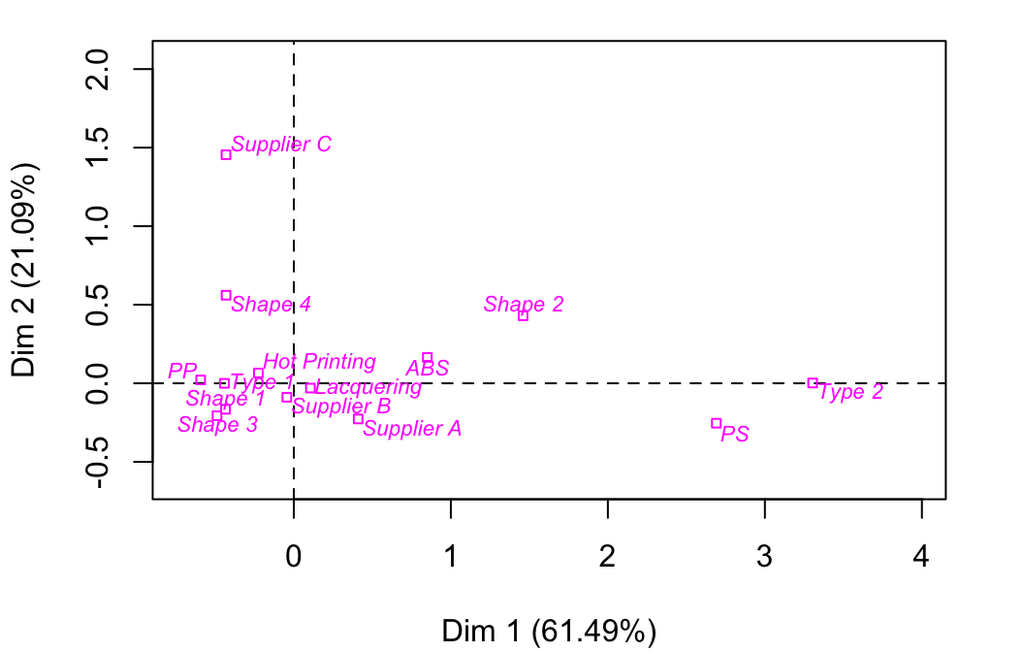

**Figure 3.4 - Qualitative factor map (PCA)** *The labeled factors are those the best shown on the plane.*

The **dimension 1** opposes individuals such as *131*, *163*, *164*, *161*, *89* and *90* (to the right of the graph, characterized by a strongly positive coordinate on the axis) to individuals characterized by a strongly negative coordinate on the axis (to the left of the graph).

The group 2 (characterized by a negative coordinate on the axis) is sharing :

- high values for the variable *Mature.Volume*.
- low values for the variables *nb.of.pieces*, *Price*, *Length*, *Diameter* and *weight* (variables are sorted from the weakest).

The group 3 (characterized by a negative coordinate on the axis) is sharing :

- high values for the variable *nb.of.pieces*.
- low values for the variables *Mature.Volume*, *weight*, *Diameter* and *Length* (variables are sorted from the weakest).

### 4. Classification

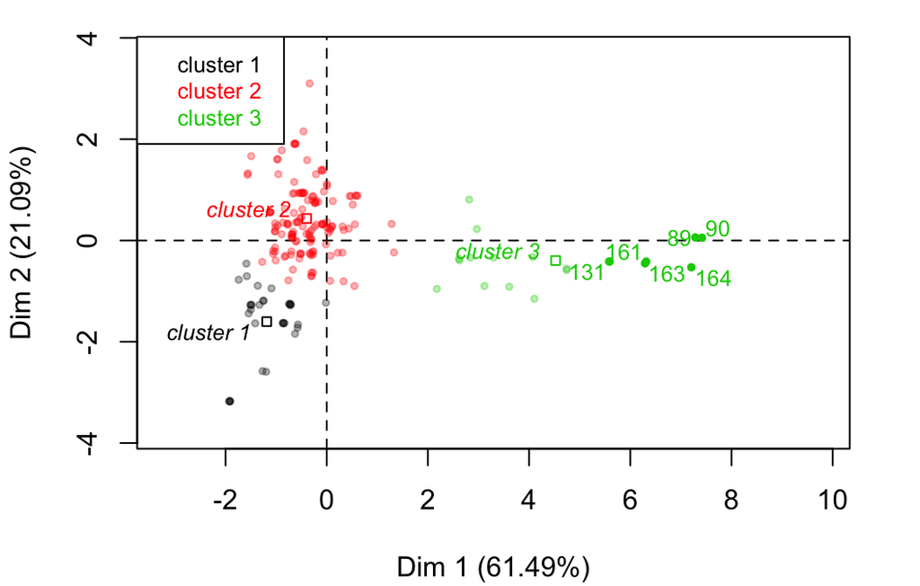

**Figure 4 - Ascending Hierarchical Classification of the individuals.** *The classification made on individuals reveals 3 clusters.*

The **cluster 1** is made of individuals sharing :

- high values for the variable *Mature.Volume*.
- low values for the variables *nb.of.pieces*, *Price*, *weight*, *Length* and *Diameter* (variables are sorted from the weakest).

The **cluster 2** is made of individuals sharing :

- high values for the variable *nb.of.pieces*.
- low values for the variables *Mature.Volume*, *Diameter*, *Length*, *weight* and *Price* (variables are sorted from the weakest).

The **cluster 3** is made of individuals such as *89*, *90*, *131*, *161*, *163* and *164*. This group is characterized by :

- high values for the variables *Length*, *Diameter*, *weight* and *Price* (variables are sorted from the strongest).
- low values for the variables *nb.of.pieces* and *Mature.Volume* (variables are sorted from the weakest).

## Annexes

```r
dimdesc(res, axes = 1:1)
```

```
$Dim.1
$Dim.1$quanti
              correlation       p.value
Length          0.9868154 1.327548e-154
Diameter        0.9867048 2.957177e-154
weight          0.9783345 5.790068e-134
Price           0.7958536  6.353362e-44
nb.of.pieces   -0.2080866  3.510303e-03
Mature.Volume  -0.3560437  3.250567e-07

$Dim.1$quali
                      R2      p.value
Impermeability 0.4748655 8.394412e-29
Raw.Material   0.4262220 6.908921e-24
Shape          0.2079756 1.099068e-09

$Dim.1$category
          Estimate      p.value
Type 2   1.8730780 8.394412e-29
PS       1.7082930 1.319147e-20
Shape 2  1.4339074 2.097828e-11
ABS     -0.1323944 1.858104e-02
Shape 1 -0.4611778 1.214250e-07
PP      -1.5758986 1.718317e-20
Type 1  -1.8730780 8.394412e-29
```

**Figure 5 - List of variables characterizing the dimensions of the analysis.**

```r
res.hcpc$desc.var
```

```
$test.chi2
                    p.value df
Impermeability 2.248178e-18  2
Raw.Material   3.404536e-17  4
Shape          1.714710e-06  6
Finishing      4.171128e-02  2

$category
$category$`1`
                        Cla/Mod    Mod/Cla   Global      p.value    v.test
Shape=Shape 1         23.880597  96.969697 68.71795 2.180291e-05  4.245580
Raw.Material=PP       21.621622  96.969697 75.89744 6.373067e-04  3.415219
Impermeability=Type 1 19.186047 100.000000 88.20513 1.053183e-02  2.557861
Raw.Material=PS        3.846154   3.030303 13.33333 4.573730e-02 -1.997810
Raw.Material=ABS       0.000000   0.000000 10.76923 1.606023e-02 -2.407544
Impermeability=Type 2  0.000000   0.000000 11.79487 1.053183e-02 -2.557861
Shape=Shape 2          2.222222   3.030303 23.07692 9.958357e-04 -3.291701

$category$`2`
                         Cla/Mod   Mod/Cla    Global      p.value
Impermeability=Type 1   77.32558 94.326241 88.205128 7.745553e-05
Raw.Material=PP         77.70270 81.560284 75.897436 4.143170e-03
Supplier=Supplier C    100.00000  9.929078  7.179487 8.839158e-03
Finishing=Hot Printing  83.87097 36.879433 31.794872 1.272595e-02
Finishing=Lacquering    66.91729 63.120567 68.205128 1.272595e-02
Raw.Material=PS         38.46154  7.092199 13.333333 1.204039e-04
Impermeability=Type 2   34.78261  5.673759 11.794872 7.745553e-05
                          v.test
Impermeability=Type 1   3.952140
Raw.Material=PP         2.867050
Supplier=Supplier C     2.618213
Finishing=Hot Printing  2.491348
Finishing=Lacquering   -2.491348
Raw.Material=PS        -3.845302
Impermeability=Type 2  -3.952140

$category$`3`
                         Cla/Mod   Mod/Cla   Global      p.value    v.test
Impermeability=Type 2 65.2173913 71.428571 11.79487 2.119196e-12  7.026407
Raw.Material=PS       57.6923077 71.428571 13.33333 3.042971e-11  6.644476
```

[output cut: 52 more lines]

```
weight        12.383169         4.680731     1.700704   1.164251e+00
Price          9.387329        30.295414    16.443852   8.814239e+00
Mature.Volume -2.719799     20542.857143 96930.005128   1.547128e+04
nb.of.pieces  -3.684915         3.047619     4.112821   7.221786e-01
                Overall sd      p.value
Length        7.804498e+00 1.799614e-35
Diameter      9.746250e-01 1.899558e-35
weight        1.164460e+00 3.223587e-35
Price         7.139907e+00 6.154086e-21
Mature.Volume 1.359000e+05 6.532170e-03
nb.of.pieces  1.398750e+00 2.287791e-04


attr(,"class")
[1] "catdes" "list "
```

**Figure 6 - List of variables characterizing the clusters of the classification.**